# EkinHW3Yeniden

```r
}
#Hour 22
PredictedValuesHour = predict(regressionbasichour22, newdata = testdata22)
for(i in 1:25){
  ErrorRegressionHourly[i] = ErrorRegressionHourly[i] + abs(((testdata22$ActualConsumption[i] - PredictedValuesHour)/testdata22$ActualConsumption[i])*100)
}
ErrorRegressionHour22 = ErrorRegressionHourly
for(i in 1:25){
  ErrorRegressionHourly[i] =  0
}
#Hour 23
PredictedValuesHour = predict(regressionbasichour23, newdata = testdata23)
for(i in 1:25){
  ErrorRegressionHourly[i] = ErrorRegressionHourly[i] + abs(((testdata23$ActualConsumption[i] - PredictedValuesHour)/testdata23$ActualConsumption[i])*100)
}
ErrorRegressionHour23 = ErrorRegressionHourly
for(i in 1:25){
  ErrorRegressionHourly[i] =  0
}
#Hour 24
PredictedValuesHour = predict(regressionbasichour24, newdata = testdata24)
for(i in 1:25){
  ErrorRegressionHourly[i] = ErrorRegressionHourly[i] + abs(((testdata24$ActualConsumption[i] - PredictedValuesHour)/testdata24$ActualConsumption[i])*100)
}
ErrorRegressionHour24 = ErrorRegressionHourly
for(i in 1:25){
  ErrorRegressionHourly[i] =  0
}

GraphHourlyRegression = 0
for(i in 1:24){
  GraphHourlyRegression[i] =  0
}
```

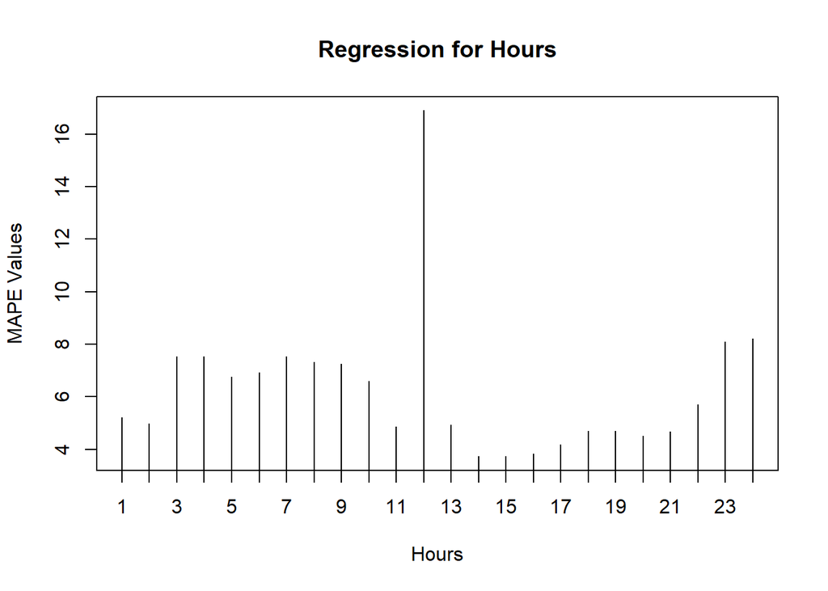

```r
Graph = c(mean(ErrorRegressionHour1), mean(ErrorRegressionHour2), mean(ErrorRegressionHour3), mean(ErrorRegressionHour4), mean(ErrorRegressionHour5), mean(ErrorRegressionHour6), mean(ErrorRegressionHour7), mean(ErrorRegressionHour8), mean(ErrorRegressionHour9), mean(ErrorRegressionHour10), mean(ErrorRegressionHour11), mean(ErrorRegressionHour12), mean(ErrorRegressionHour13), mean(ErrorRegressionHour14), mean(ErrorRegressionHour15), mean(ErrorRegressionHour16), mean(ErrorRegressionHour17), mean(ErrorRegressionHour18), mean(ErrorRegressionHour19), mean(ErrorRegressionHour20), mean(ErrorRegressionHour21), mean(ErrorRegressionHour22), mean(ErrorRegressionHour23), mean(ErrorRegressionHour24))
plot(Graph, type="h", xaxt = "n",xlab="Hours", ylab="MAPE Values", main = "Regression for Hours")
axis(side=1,at=seq(1:24))
```

## Part d

Since I do not have knowledge about packages in R, I just created my wide matrix with for loops. You can check wideMatrix. :)

```r
wideMatrix = matrix(nrow = 34176, ncol=48)
dummyIndex = 1
rowOperator = 169
for(i in 1:34176){
  for(j in 1:48){
    if(i<=168){
      wideMatrix[i,j] = 0
    }
    else{
      if(j<=24)
      {
        wideMatrix[i,j] = alldata$ActualConsumption[rowOperator-48+j-1]
      }
      else
      {
        wideMatrix[i,j] = alldata$ActualConsumption[rowOperator-168+j-1-24]
      }
    }
  }
  if(i>168)
  {
    dummyIndex = dummyIndex + 1
    if(dummyIndex >24)
    {
      dummyIndex = 1
      rowOperator = rowOperator + 24
    }
  }
}

wideMatrix = as.data.table(wideMatrix)
wideTrainingMatrix = rbind(wideMatrix[169:33576])
wideTestMatrix = rbind(wideMatrix[33577:34176])
#First 168 entries and test interval is excluded.
head(wideTrainingMatrix)
```

```
##          V1       V2       V3       V4       V5       V6       V7       V8
## 1: 29189.27 27614.02 26578.97 25719.19 25864.63 25918.59 27091.94 28533.05
## 2: 29189.27 27614.02 26578.97 25719.19 25864.63 25918.59 27091.94 28533.05
## 3: 29189.27 27614.02 26578.97 25719.19 25864.63 25918.59 27091.94 28533.05
## 4: 29189.27 27614.02 26578.97 25719.19 25864.63 25918.59 27091.94 28533.05
## 5: 29189.27 27614.02 26578.97 25719.19 25864.63 25918.59 27091.94 28533.05
## 6: 29189.27 27614.02 26578.97 25719.19 25864.63 25918.59 27091.94 28533.05
##          V9      V10      V11      V12      V13      V14      V15      V16
## 1: 33203.34 36257.22 37212.91 37844.74 36194.13 36542.73 36847.22 36433.88
## 2: 33203.34 36257.22 37212.91 37844.74 36194.13 36542.73 36847.22 36433.88
## 3: 33203.34 36257.22 37212.91 37844.74 36194.13 36542.73 36847.22 36433.88
## 4: 33203.34 36257.22 37212.91 37844.74 36194.13 36542.73 36847.22 36433.88
## 5: 33203.34 36257.22 37212.91 37844.74 36194.13 36542.73 36847.22 36433.88
## 6: 33203.34 36257.22 37212.91 37844.74 36194.13 36542.73 36847.22 36433.88
##         V17      V18   V19      V20   V21      V22      V23      V24      V25
```

[output cut: 27 more lines]

```r
#Every consecutive 24 row has same values, since they all share same date.
#Row operator increases by 24 after a day passed. DummyIndex controls this mod process.
```

Lets begin Lasso regression.

```r
lassoMatrix = cbind(regressiondata,wideTrainingMatrix)
lassoTestMatrix = cbind(testdata,wideTestMatrix)
#Verification of wideMatrix can be done by comparing lag_48 & lag_168 values with newly added for loop values.
#Double check is done, wide matrices are correct! So proud.


lassoTestMatrix$Prediction = 0


lambdalist = data.table(model = paste0("LassoModel-",c(0:23)),lambdavalues = numeric(), lambdamin = numeric())
```

```r
lassoTestMatrix$Saat = as.numeric(lassoTestMatrix$Saat)
lassoMatrix$Saat = as.numeric(lassoMatrix$Saat)

LassoTestHourly = split(lassoTestMatrix,lassoTestMatrix$Saat)
LassoTrainHourly = split(lassoMatrix,lassoMatrix$Saat)

set.seed(523)

resultLasso = subset(lassoTestMatrix[c(2,3)])
resultLasso$ActualConsumption = 0
resultLassoHourly = split(resultLasso, resultLasso$Saat)

xtest=lassoTestMatrix[c(7:54)]

errorLassoHourly = vector(mode="list", length = 24)
MAPEList = vector(mode = "list", length = 24)
Coefficients = vector(mode = "list", length = 25)

for(i in 1:24){
  x=as.matrix(LassoTrainHourly[[i]][c(7:54)])
  y=LassoTrainHourly[[i]]$ActualConsumption
  LassoModel = cv.glmnet(x,y,type.measure = "mse", alpha=1,family="gaussian", nfolds=10)
  assign(paste0("LassoModel",i),LassoModel)
  resultLassoHourly[[i]]$ActualConsumption = predict(LassoModel, newx = as.matrix(LassoTestHourly[[i]][c(7:54)]), s="lambda.1se")
  lambdalist[i]$lambdamin = LassoModel$lambda.min
  lambdalist[i]$lambdavalues = LassoModel$lambda.1se

  Coefficients[[i]] = coef(LassoModel)
  errorLassoHourly[[i]] = resultLassoHourly[[i]]$ActualConsumption - LassoTestHourly[[i]]$ActualConsumption
  MAPEList[[i]] = sum(abs(errorLassoHourly[[i]]/LassoTestHourly[[i]]$ActualConsumption))*100/25
}
```

### Coefficients, lambda values, MAPES are collected via only 1 for loop. Let’s try to visualize them

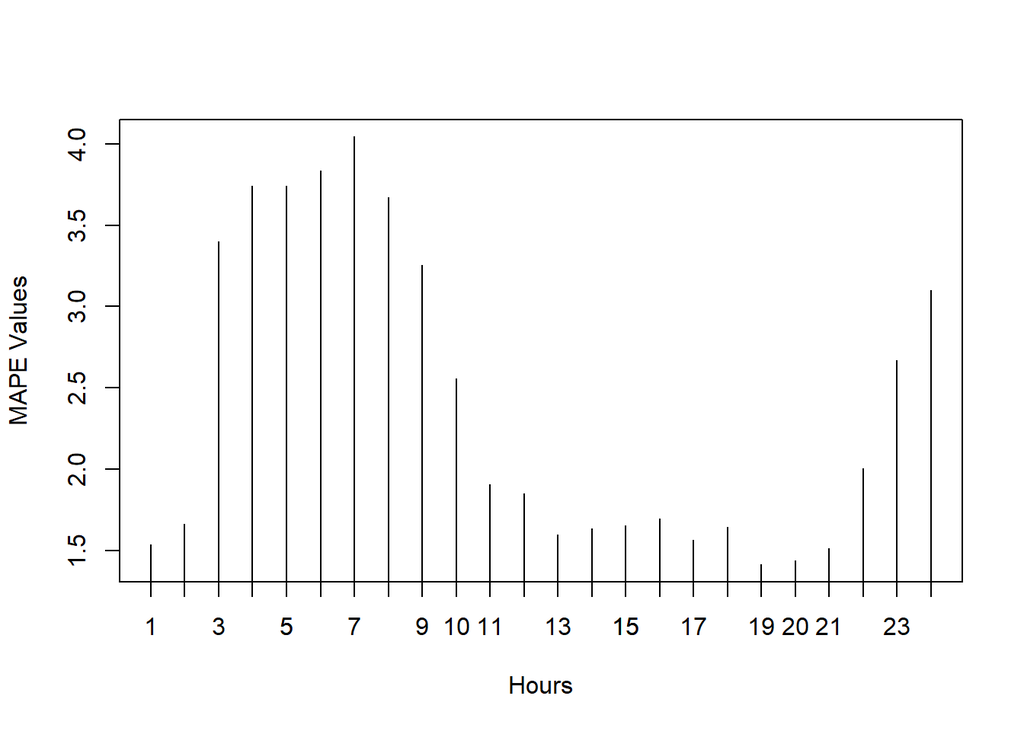

```r
plot(x=seq(1,24,1),MAPEList, type="h", xlab="Hours", ylab="MAPE Values")
axis(side=1,at=seq(1:24))
```

As you can see from the plot above, predicting afternoon hours are easier.

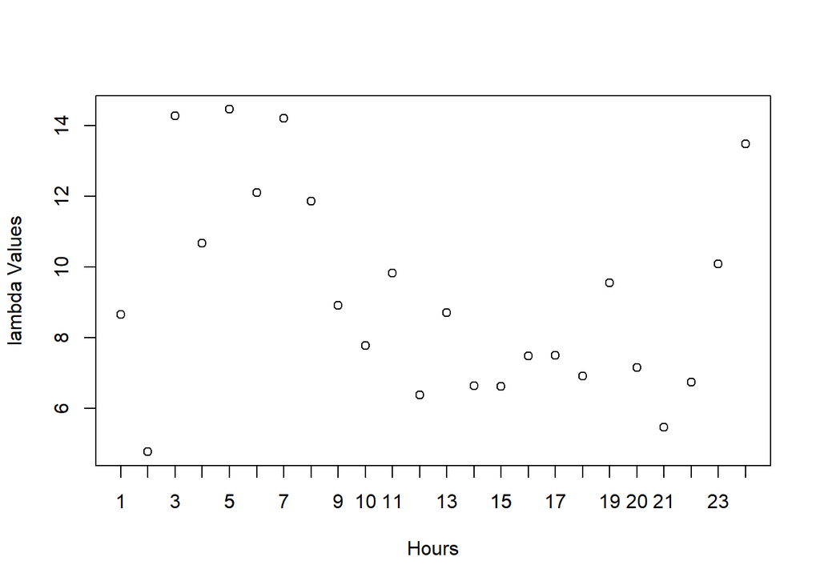

```r
plot(lambdalist$lambdavalues, xlab="Hours", ylab="lambda Values")
axis(side=1,at=seq(1:24))
```

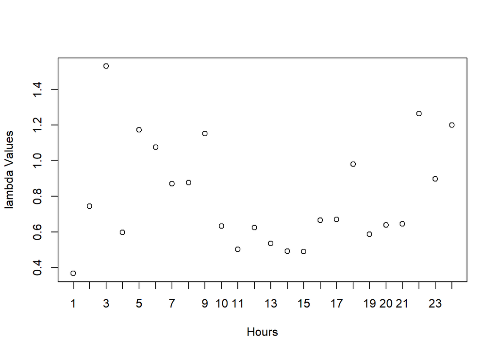

```r
plot(lambdalist$lambdamin, xlab="Hours", ylab="lambda Values")
axis(side=1,at=seq(1:24))
```

Both lambda values and minimum lambdas are decreasing in the afternoon. Summary of the coefficients can be seen below. First element is intercept.

### Important note: If consumptions are scaled with respect to mean and standard deviations, the results may change. Lasso penalization mechanism would change.

```r
for(i in 1:24){
  print(summary(Coefficients[[i]]))
}
```

```
## 49 x 1 sparse Matrix of class "dgCMatrix", with 20 entries
##     i j             x
## 1   1 1  1.430279e+03
## 2   2 1 -1.220067e-01
## 3   3 1 -2.526392e-02
## 4   9 1  1.335748e-01
## 5  11 1 -5.338512e-01
## 6  12 1 -7.731912e-02
## 7  15 1  1.845225e-01
## 8  19 1  2.539182e-02
## 9  23 1  9.654502e-03
## 10 24 1  2.983288e-01
## 11 25 1  1.023669e+00
## 12 26 1  6.061154e-02
## 13 32 1  1.574801e-01
```

[output cut: 591 more lines]

Plots of the models can be seen below.

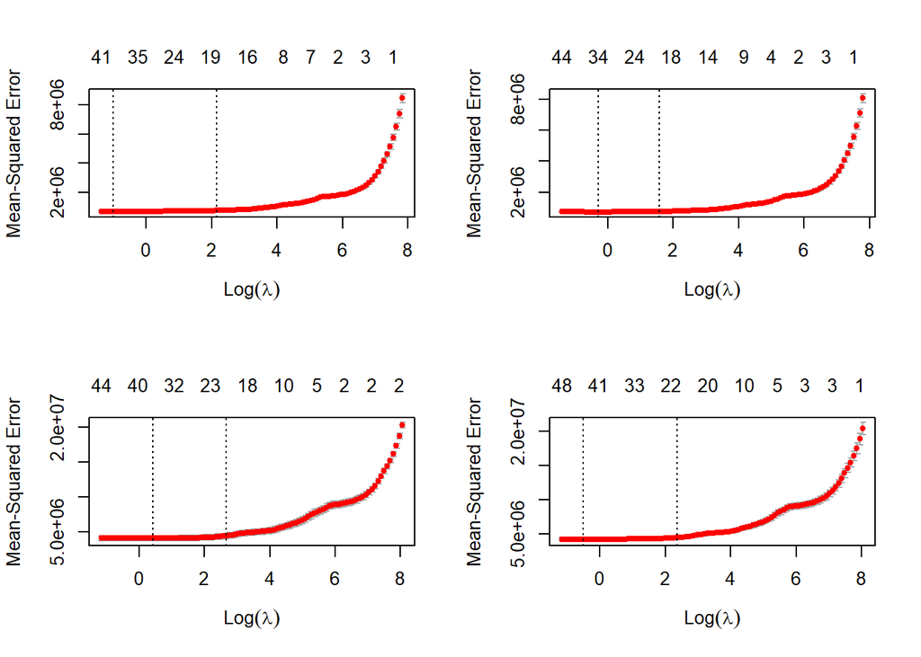

```r
par(mfrow = c(2,2))
plot(LassoModel1)
plot(LassoModel2)
plot(LassoModel3)
plot(LassoModel4)
```

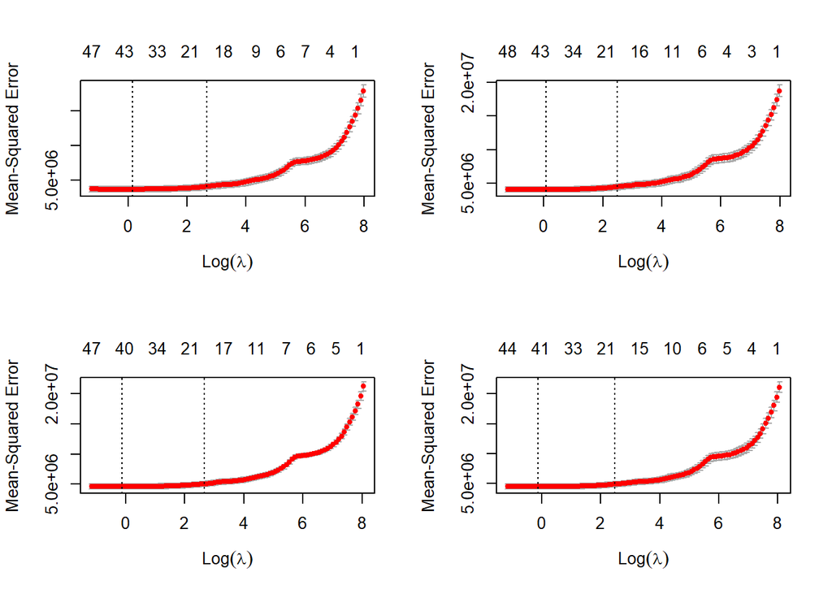

```r
plot(LassoModel5)
plot(LassoModel6)
plot(LassoModel7)
plot(LassoModel8)
```

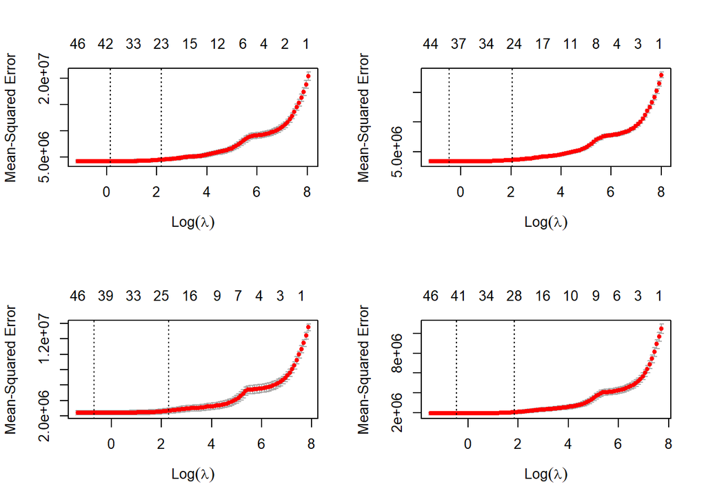

```r
plot(LassoModel9)
plot(LassoModel10)
plot(LassoModel11)
plot(LassoModel12)
```

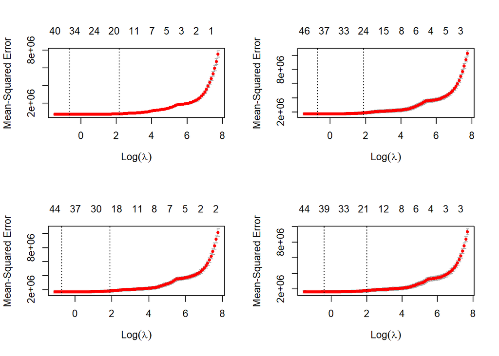

```r
plot(LassoModel13)
plot(LassoModel14)
plot(LassoModel15)
plot(LassoModel16)
```

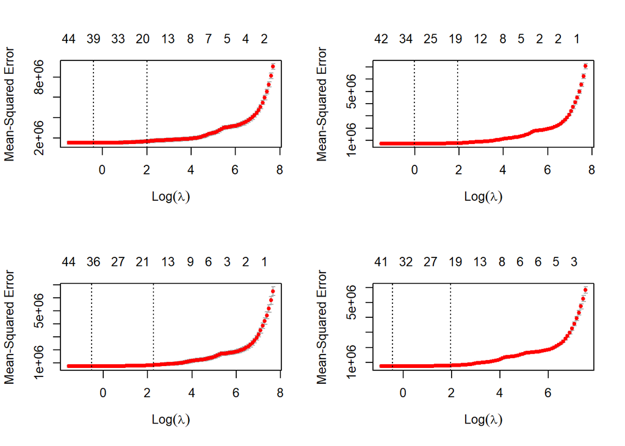

```r
plot(LassoModel17)
plot(LassoModel18)
plot(LassoModel19)
plot(LassoModel20)
```

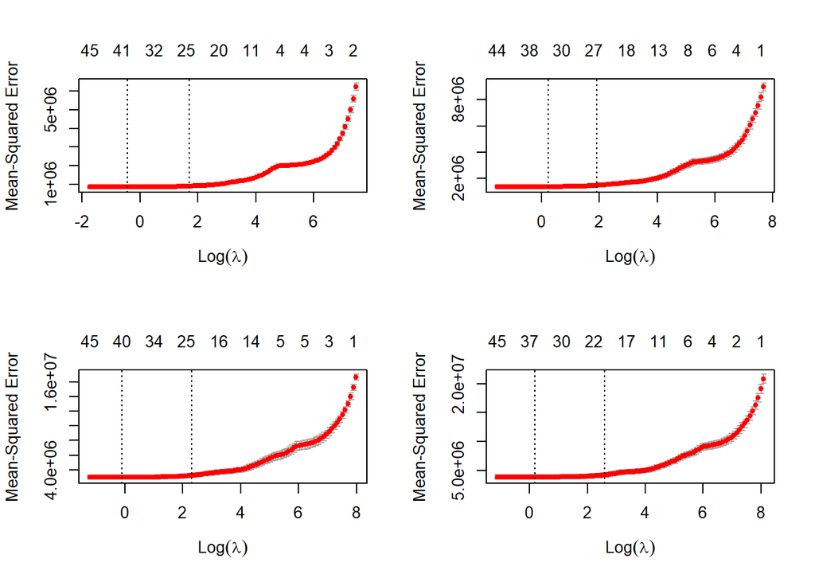

```r
plot(LassoModel21)
plot(LassoModel22)
plot(LassoModel23)
plot(LassoModel24)
```

```r
dev.off()
```

## Part F

### Comparison of MAPE values

As you can see the graph below which is constructed by gathering all types of errors in same plot, Lasso regression seem to have best result. On the other hand, lag_168 naive approach prediction is quite well. Scaling Lasso regressions may change the result. However, for the sake of simplicity, I would prefer lag_168 naive approach.

```r
MAPElassoError = 0
for(i in 1:24){
  MAPElassoError[i] = 0
}
for(i in 1:24){
  MAPElassoError[i] = mean(MAPEList[[i]])
}

errors = data.frame(MAPElag48 = ErrorNaive2Days, MAPElag168 = ErrorNaive7Days, MAPElinearreg = ErrorRegression, MAPEhourlylinearreg = Graph, MAPElasso = MAPElassoError)
summary(errors)
```

```
##    MAPElag48          MAPElag168        MAPElinearreg       MAPEhourlylinearreg
##  Min.   : 0.00164   Min.   : 0.005252   Min.   : 0.002712   Min.   : 3.733
##  1st Qu.: 1.13099   1st Qu.: 0.927704   1st Qu.: 5.676226   1st Qu.: 4.686
##  Median : 5.96517   Median : 1.899001   Median :12.300596   Median : 5.467
##  Mean   : 7.78615   Mean   : 2.992843   Mean   :11.777505   Mean   : 6.264
##  3rd Qu.: 9.67791   3rd Qu.: 3.586294   3rd Qu.:16.625918   3rd Qu.: 7.369
##  Max.   :41.82994   Max.   :21.199935   Max.   :27.932279   Max.   :16.898
##    MAPElasso
##  Min.   :1.413
##  1st Qu.:1.625
##  Median :1.878
##  Mean   :2.380
##  3rd Qu.:3.292
##  Max.   :4.044
```

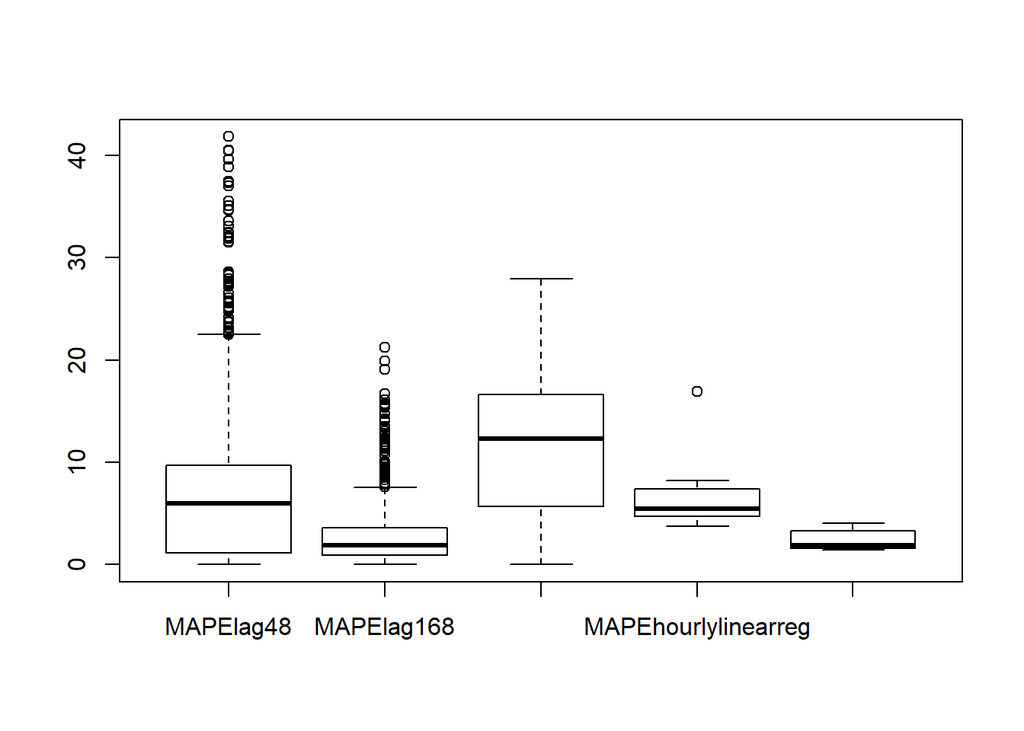

```r
boxplot(errors)
```